# `python` basics

[figure not shown]

**Matthias König** (https://livermetabolism.com, [#konigmatt](https://twitter.com/konigmatt))

Resources available from: https://github.com/matthiaskoenig/python-introduction

## Python features

- `python` is easy to learn, highly readable, and simple to use
- clean coding style:
  - no `;`,
  - no brackets, but intendation
  - English language
- best language for beginners; fast learning curve
- highly prevalent in data science, data analysis, bioinformatics, biology
- allows for scripting and high-level object oriented programming

[figure not shown]

## What we will learn

- Variables and Types
- Lists and Dictionaries
- Basic Operators
- Basic String Operations
- Conditions
- Loops
- Functions
- Classes and Objects
- Dictionaries
- Modules and Packages

## Many online resource

Good interactive python tutorials can be found online. For instance at https://www.learnpython.org/.

An overview of tutorials can be found here https://digitaldefynd.com/best-free-python-tutorials/.

Very simple to self-study and get up to speed!

## System setup

- We will work with `python3`, so you should have an installation of `python 3.7`, `3.8` or `3.9`. Anaconda is the simplest way to get a working installation.
- You should use an editor/frontend to write the code (syntax highlighting, autocomplete)
  - `jupyter lab` or `jupyter notebook`
  - `pycharm`
  - `spyder`
  - `visual studio code`
- At this point you should have a running installation and be able to execute the following

```python
print("Hello world")
```

```
Hello world
```

## Variables and assignments

The core building blocks of programmings are **variables**. Variables are boxes in which you can store something. The process of putting something in the varible (box) is called **assignment**.

[figure not shown]

- python is dynamically typed (not necessary to provide the type of the variable/box)
- assignments create variables with the correct type

Python has built in support for the basic data types like `boolean`, `integer`, `float`; strings `str`; more complex data structures such as `list`, `set` and `dict`.

First we store an integer (`int`) in the variable `myNum`. We can print the content of a variable using `print`. We can check the type using `type`.

[figure not shown]

```python
myNum = 4
print(myNum)
```

```
4
```

```python
type(myNum)
```

```
int
```

We can change the value of the variable by assigning a different value.

[figure not shown]

```python
myNum = 4
myNum = 5
print(myNum)
```

```
5
```

We change the type of the variable by assigning a different data type (`float`). The boxes are dynamic, i.e., variables can store anything.

```python
myNum = 4.0
print(myNum)
```

```
4.0
```

```python
type(myNum)
```

```
float
```

A boolean variable

```python
x = True
print(x, type(x))
```

```
True <class 'bool'>
```

We can assign more complex things then just a number. Here we use the value of var to update var

```python
var1 = 4
var2 = var1 + 2
print(var2)
var2 = var2 + 2
print(var2)
```

```
6
8
```

**Summary**

- Variables are boxes
- The type of the box is defined by what you put in the box
- You can use complex assignments

[figure not shown]

```python
myInt = 4
myFloat = 2.5
myChar = "a"
myString = "hello"
print(myInt, myFloat, myChar, myString)
```

```
4 2.5 a hello
```

For more information see: https://www.learnpython.org/en/Variables_and_Types

## Operators

- operators allow to combine expressions
- examples are `+`, `-`, `*`, ...
- the meaning of the operators depends on the type

```python
var = 4
print(var + 2)
```

```
6
```

## More complex data types

- strings, lists, tuples, dictionaries

An important data type are strings (`str`). These can be defined using eithe `"` or `'` around the string.

```python
# define two strings and combine them
text1 = "Hel"
text2 = "lo"
text = text1 + text2
print(text)
```

```
Hello
```

```python
type(text)
```

```
str
```

The different data types have their own functionality. This is provided by functions. The arguments to the function are given within the brackets after the function name.

For instance a string has a method `find` which we can use to find the occurrence of substrings

```python
text.find("o")
```

```
4
```

### Getting help

By prepending a library, method or variable with `?`, you can access a quick reference on syntax.

```python
help(text.find)
```

```
Help on built-in function find:

find(...) method of builtins.str instance
    S.find(sub[, start[, end]]) -> int

    Return the lowest index in S where substring sub is found,
    such that sub is contained within S[start:end].  Optional
    arguments start and end are interpreted as in slice notation.

    Return -1 on failure.
```

```python
# same works for objects
help(list)
```

[output not shown]

[output cut: 34 more lines]

```
 |      Reverse *IN PLACE*.
 |  sort(self, /, *, key=None, reverse=False)
 |      Sort the list in ascending order and return None.
 |      The sort is in-place (i.e. the list itself is modified) and stable (i.e. the
 |      order of two equal elements is maintained).
 |      If a key function is given, apply it once to each list item and sort them,
 |      ascending or descending, according to their function values.
 |      The reverse flag can be set to sort in descending order.
 |  ----------------------------------------------------------------------
 |  Static methods defined here:
 |  __new__(*args, **kwargs) from builtins.type
 |      Create and return a new object.  See help(type) for accurate signature.
 |  ----------------------------------------------------------------------
 |  Data and other attributes defined here:
 |  __hash__ = None
```

### Lists

An important data type is the `list`, which is defined using `[ ]` brackets.

- a list is a container for multiple objects (many boxes together)
- the boxes can be accessed via their index

[figure not shown]

```python
x = 1.2
y = 3.4
print([x+y, x*y, x**y])
```

```
[4.6, 4.08, 1.858729691979481]
```

```python
vec = [2, 3.4 , 7 , 0.5]
print(vec)
```

```
[2, 3.4, 7, 0.5]
```

We can access elements in the list based on the `index`. The index is zero-based, i.e., we start counting at 0

```python
vec[0]
```

```
2
```

```python
vec[3]
```

```
0.5
```

```python
vec[3] = 1.5
print(vec)
```

```
[2, 3.4, 7, 1.5]
```

```python
print(vec[0:3])
```

```
[2, 3.4, 7]
```

```python
l1 = [1, 2]
l2 = [2, 3]
print(l1+l2)
```

```
[1, 2, 2, 3]
```

```python
help(list)
```

[output not shown]

[output cut: 34 more lines]

```
 |      Reverse *IN PLACE*.
 |  sort(self, /, *, key=None, reverse=False)
 |      Sort the list in ascending order and return None.
 |      The sort is in-place (i.e. the list itself is modified) and stable (i.e. the
 |      order of two equal elements is maintained).
 |      If a key function is given, apply it once to each list item and sort them,
 |      ascending or descending, according to their function values.
 |      The reverse flag can be set to sort in descending order.
 |  ----------------------------------------------------------------------
 |  Static methods defined here:
 |  __new__(*args, **kwargs) from builtins.type
 |      Create and return a new object.  See help(type) for accurate signature.
 |  ----------------------------------------------------------------------
 |  Data and other attributes defined here:
 |  __hash__ = None
```

Lists are just mutable containers (we can store anything in them and as much as we want)

```python
mixlist = [True, 1, 3.4, "text"]
print(mixlist)
```

```
[True, 1, 3.4, 'text']
```

### Dictionaries

Another important data type are dictionaries, which allow to lookup thing based on keys

```python
d = {
    "apple": 4,
    "orange": 3,
    "melon": 10
}
print(d)
```

```
{'apple': 4, 'orange': 3, 'melon': 10}
```

```python
d['orange']
```

```
3
```

## Workspaces

- an important concept in programming is modularization, i.e., creating building blocks, reusing them and combining them
- `functions`, `modules` and `packages` are the main building blocks

In addition to built-in functions, we can use our own functions and scripts. In general commands placed in a file can be executed as if typed directly in the command line. We can write code in external files with ending `.py` and execute these.

[output not shown]

```python
import os
print(os.getcwd())
```

```
/home/mkoenig/git/python-introduction/notebooks
```

```python
!python examplescript.py
```

```
[4.8, 4.76, 3.139318080476335]
```

When we import the module all statements are executed in the file (but only on first import)

```python
import examplescript
```

```
[4.8, 4.76, 3.139318080476335]
```

An important trick for notebooks is to reload the external modules

```python
import importlib
importlib.reload(examplescript)
```

```
[4.8, 4.76, 3.139318080476335]
```

```
<module 'examplescript' from '/home/mkoenig/git/python-introduction/notebooks/examplescript.py'>
```

### Functions

An important construct are functions

- defined via `def` keyword
- have parameters/arguments which add information in the function
- have a `return` statement which allows to return information

```python
def square_it(x):
    """Returns the square of x"""
    y = x**2
    return y
```

```python
type(square_it)
```

```
function
```

```python
help(square_it)
```

```
Help on function square_it in module __main__:

square_it(x)
    Returns the square of x
```

```python
z = square_it(10)
print(z)
```

```
100
```

### Modules, libraries and imports

Modules are python files with code. These can be reused.

A library is a collection of modules for a specific purpose or domain.

Within the course we will use the following libraries

- `numpy`: numerical methods and data structures (e.g. vectors and matrices)
- `scipy`: scientific methods (e.g. interpolation)
- `matplotlib`: plotting functionality (e.g. plotting curves)
- `pandas`: data structures for working with Data (e.g. 2D tables)

To import an external library use the `import` statement

```python
import numpy
import scipy
import matplotlib
```

We can define functions in external modules and than just import them

```python
import my_functions
importlib.reload(my_functions)

my_functions.simple_sum(4, 3)
```

```
7
```

```python
import my_functions as mf
importlib.reload(mf)

a = 5
z = mf.simple_sum(a,3)
z
```

```
8
```

```python
g = mf.simple_sum(a,-3)
g
```

```
2
```

## Flow control

In addition we need statements that control the flow of a program (`if`, `for`, `while`).

```python
for k in range(5):
    if k != 3:
        print(k)
    else:
        print("do not print")
```

```
0
1
2
do not print
4
```

## Plots

- `matplotlib` is one of the main packages to create plots
- `numpy` is the main numeric library for python (support for vectors, matrices, ...)

[figure not shown]

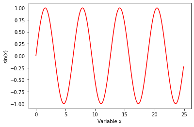

```python
# allow inline plotting in notebook
%matplotlib inline

# import libraries
import numpy as np
import matplotlib.pyplot as plt

# create x and y data
x = np.arange(0, 25, 0.1)
y = np.sin(x)

# plot curve
plt.plot(x, y, 'r-')
plt.xlabel('Variable x')
plt.ylabel('sin(x)')
plt.show()
```

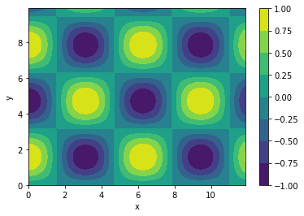

```python
# a more complicated plot
x = np.arange(0,12,0.1)
y = np.arange(0,10,0.1)
xx, yy = np.meshgrid(x,y)
z = np.sin(yy)*np.cos(xx)
cp = plt.contourf(xx,yy,z)
plt.xlabel('x')
plt.ylabel('y')
plt.colorbar(cp)
plt.show()
```